# Unit 11 - Panel Data

James Flynn

October 14, 2026

## Panel Data - Motivation

- We introduced the **selection bias** problem earlier
- It will show up again and again
- Much of the rest of the course will be about dealing with it
- Each method will require different assumptions
- Panel Data provides one of the simplest solutions
- But with possibly the most strict assumptions

## Panel Data - Setup

- With selection bias, we are concerned that the error term is correlated with treatment
- in DAG form, $Y_i \leftarrow u_i \rightarrow D_i$
- This causes treatment to look more/less effective than it is
- It turns out, this is OK if:
  - $u_i$ is constant over time
  - We have data from many periods
  - With variation in treatment
  - With repeated observations for individuals

## Why does this work

- This allows us to track individuals over time
- In all periods, $u_i$ plays a role
- **BUT** that role is constant over time
- While treatment is not
- This allows us to compare the same person (or unit)
- Both while treated and not treated
- Or with varying levels of treatment

## What does panel data look like?

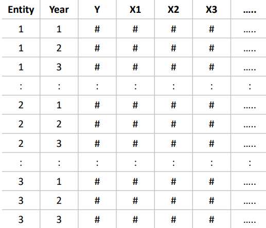

## What does this get us?

- Instead of comparing outcomes for different people
- We are comparing outcomes for the **same** person
  - Just at different times
- The $u_i$ effect will cancel out
- Even if their is selection into treatment, we can get a causal estimate

## Consider this DAG from the CI Mixtape

- Dotted lines mean the relationship is *unobserved*

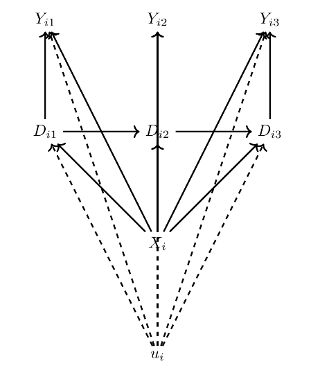

## Let’s explore using the [Panel Study of Income Dynamics](https://psidonline.isr.umich.edu/)

```r
library(ggplot2)
library(tidyverse)
library(modelsummary)

psid <- haven::read_dta("PSID_97_01.dta")
head(psid)
```

```
## # A tibble: 6 × 18
##      id  year   age marst  work union salary  wage tenure weight heightft
##   <dbl> <dbl> <dbl> <dbl> <dbl> <dbl>  <dbl> <dbl>  <dbl>  <dbl>    <dbl>
## 1    33  1997    34     1     0     0      0  10.5      5     NA       NA
## 2    33  1999    36     1     0     0      0  12.0      6    172        6
## 3    33  2001    38     1     0     0      0  13.6     10    172        6
## 4    75  1997    31     2     0     0  14000   0        7     NA       NA
## 5    75  1999    33     2     0     0  16000   0       10    145        5
## 6    75  2001    35     2     0     0  19000   0       10    150        5
## # ℹ 7 more variables: heightin <dbl>, education <dbl>, married <dbl>,
## #   hourwage <dbl>, logwage <dbl>, heightinches <dbl>, count <dbl>
```

## We will use this data to explore the **marriage premium**

- What is the marriage premium?
- How might **selection bias** show up?
- Observable or unobservable (or both?)
- Do we see how the panel data setup can fix this?

## Let’s start by just regressing wages on marital status

```r
lm_biased <- lm(logwage ~ married, data=psid)
summary(lm_biased)
```

```
##
## Call:
## lm(formula = logwage ~ married, data = psid)
##
## Residuals:
##      Min       1Q   Median       3Q      Max
## -2.78938 -0.32917  0.03421  0.40480  1.68573
##
## Coefficients:
##             Estimate Std. Error t value Pr(>|t|)
## (Intercept)  2.52099    0.01830   137.8   <2e-16 ***
## married      0.29309    0.02237    13.1   <2e-16 ***
## ---
## Signif. codes:  0 '***' 0.001 '**' 0.01 '*' 0.05 '.' 0.1 ' ' 1
##
## Residual standard error: 0.6752 on 4114 degrees of freedom
## Multiple R-squared:  0.04006,    Adjusted R-squared:  0.03983
## F-statistic: 171.7 on 1 and 4114 DF,  p-value: < 2.2e-16
```

## Married people earn $\approx$ 29% more

- We can improve on this
- Let’s start by adding control variables
- We have education, age, and job tenure
- We will also add year FEs to control for inflation

## Adding controls

```r
lm_1 <- lm(logwage ~ married, data=psid)
lm_2 <- lm(logwage ~ married + education + age + tenure, data=psid)
lm_3 <- lm(logwage ~ married + education + age + tenure + factor(year), data=psid)
msummary(list(lm_1,lm_2,lm_3), coef_omit= 3:7, stars = TRUE, gof_omit = 'AIC|BIC|Lik|Adj.|F')
```

|  | (1) | (2) | (3) |
| --- | --- | --- | --- |
| (Intercept) | 2.521*** | 0.987*** | 0.965*** |
|  | (0.018) | (0.071) | (0.071) |
| married | 0.293*** | 0.233*** | 0.234*** |
|  | (0.022) | (0.021) | (0.021) |
| Num.Obs. | 4116 | 4116 | 4116 |
| R2 | 0.040 | 0.169 | 0.181 |
| RMSE | 0.68 | 0.63 | 0.62 |

+ p < 0.1, * p < 0.05, ** p < 0.01, *** p < 0.001

## Let’s take a closer look

```r
lm_3 <- lm(logwage ~ married + education + age + tenure + factor(year), data=psid)
summary(lm_3)$coefficients
```

```
##                     Estimate  Std. Error   t value      Pr(>|t|)
## (Intercept)      0.965419630 0.071435997 13.514470  9.427375e-41
## married          0.233681836 0.020876039 11.193782  1.132285e-28
## education        0.091607233 0.004080931 22.447631 2.301396e-105
## age              0.004261563 0.001367695  3.115872  1.846666e-03
## tenure           0.008484357 0.001345096  6.307621  3.133017e-10
## factor(year)1999 0.079022492 0.023970678  3.296632  9.868312e-04
## factor(year)2001 0.182080866 0.024388367  7.465890  1.004546e-13
```

## Now we’ll add an invididual fixed effect

- How does this change the comparison that our regression makes?
- What do we think will happen?

## How does that change things

```r
m3 <- lm(logwage~married+education+age+tenure+factor(year), data=psid)
m4 <- lm(logwage~married+education+age+tenure+factor(year)+factor(id), data=psid)
msummary(list(m3,m4), coef_omit= 3:1377, stars = TRUE, gof_omit = 'AIC|BIC|Lik|Adj.|F')
```

|  | (1) | (2) |
| --- | --- | --- |
| (Intercept) | 0.965*** | −2.407 |
|  | (0.071) | (4.345) |
| married | 0.234*** | 0.014 |
|  | (0.021) | (0.044) |
| Num.Obs. | 4116 | 4116 |
| R2 | 0.181 | 0.751 |
| RMSE | 0.62 | 0.34 |

+ p < 0.1, * p < 0.05, ** p < 0.01, *** p < 0.001

## What are the remaining threats to identification?

- Let’s assume we still found a marriage premium
- Would we say this is causal?
- What would need to be true in order for that to be the case?

## Notice that including individual FEs is the same as **demeaning**

```r
psid <- psid %>%
  group_by(id) %>%
  mutate(logwage_dm = logwage - mean(logwage),
         education_dm = education - mean(education),
         age_dm = age - mean(age),
         tenure_dm = tenure - mean(tenure),
         married_dm = married - mean(married))
```

## Note they are the same

```r
m4 <- lm(logwage~married+education+age+tenure+factor(year)+factor(id), data=psid)
m5 <- lm(logwage_dm~married_dm+education_dm+age_dm+tenure_dm+factor(year), data=psid)

summary(m4)$coefficients[2,1]
```

```
## [1] 0.01353227
```

```r
summary(m5)$coefficients[2,1]
```

```
## [1] 0.01353227
```

## Class exercise

- Is there a union premium?
  - Use the PSID data

## Solution

```r
m3 <- lm(logwage~union+married+education+age+tenure+factor(year), data=psid)
m4 <- lm(logwage~union+married+education+age+tenure+factor(year)+factor(id), data=psid)
msummary(list(m3,m4), coef_omit= 3:1378, stars = TRUE, gof_omit = 'AIC|BIC|Lik|Adj.|F')
```

|  | (1) | (2) |
| --- | --- | --- |
| (Intercept) | 0.941*** | −1.533 |
|  | (0.072) | (4.379) |
| union | 0.063** | 0.072 |
|  | (0.022) | (0.046) |
| Num.Obs. | 4116 | 4116 |
| R2 | 0.182 | 0.751 |
| RMSE | 0.62 | 0.34 |

+ p < 0.1, * p < 0.05, ** p < 0.01, *** p < 0.001

## Circling back

- Important to remember the causal interpretation is based on $u_i$ being constant over time
- What would it look like if that was violated in these two cases?